# R Notebook

## Área bajo la Curva

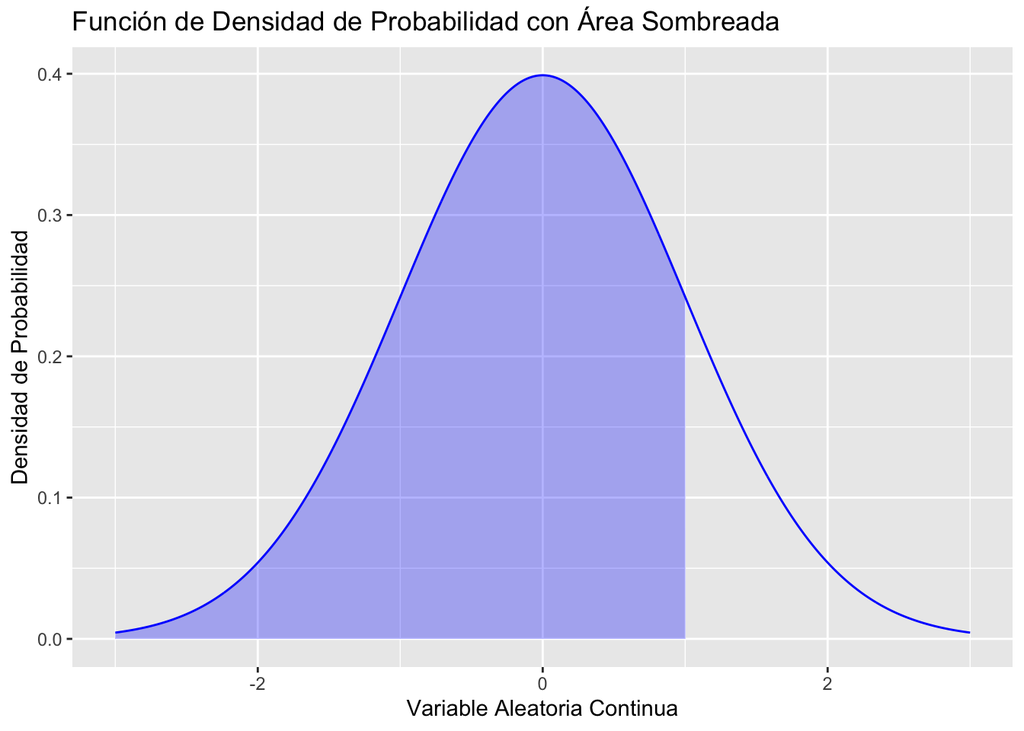

```r
# Instala ggplot2 si aún no lo tienes instalado
# install.packages("ggplot2")

# Carga la librería ggplot2
library(ggplot2)

# Valor hasta el cual deseas sombrear el área bajo la curva
valor_limite <- 1

# Crea una secuencia de valores para el eje x
x <- seq(-3, 3, length = 1000)

# Calcula la función de densidad de probabilidad (PDF) para la distribución normal estándar
pdf <- dnorm(x)

# Crea un marco de datos con los valores de x y PDF
data <- data.frame(x, pdf)

# Crea el gráfico del área bajo la curva hasta el valor límite
ggplot(data, aes(x = x, y = pdf)) +
  geom_line(color = "blue") +  # Línea de la PDF completa
  geom_area(data = subset(data, x <= valor_limite), fill = "blue", alpha = 0.3) +  # Área sombreada hasta el valor límite
  xlab("Variable Aleatoria Continua") +
  ylab("Densidad de Probabilidad") +
  ggtitle("Función de Densidad de Probabilidad con Área Sombreada")
```

# Densidad Uniforme

Recordemos que la distribución uniforme es como sigue:

$$f(x)=\begin{cases}
\frac{1}{b-a} & \text{si $a\leq x \leq b$,}\\
0 & \text{en otro caso.}
\end{cases}$$

Asociadas a esta distribución, usaremos las funciones *punif* para calcular la distribcuión acumulada, mientras que usaremos la función *qunif* para encontrar los cuantiles. Recuerde que en este caso dunif no representa $P[X=x]$.

Calculemos $P[Z\leq 2.8].$

```r
punif(2.8,min=2.5,max=3.5)
```

```
## [1] 0.3
```

Ahora Calculemos $P[Z\geq 3.3]$.

```r
1-punif(3.3,min=2.5,max=3.5)
```

```
## [1] 0.2
```

```r
punif(3.3,min=2.5,max=3.5,lower.tail = FALSE)
```

```
## [1] 0.2
```

Ahora calculemos la mediana $Z_{0.5}$.

```r
qunif(0.5,min=2.5,max=3.5)
```

```
## [1] 3
```

Finalmente, calculemos el cuantil $x_{0.75}$ o el percentil 75.

```r
qunif(0.75,min=2.5,max=3.5)
```

```
## [1] 3.25
```

El cuantil $x_{0.75}$ o percentil 75, que es 3.25, es el peso de un niño cualquiera entre 0 y meses tal que supera al $75\%$ de los pesos de otros niños, y equivalentemente, 3.25 es el peso de un niño entre 0 y 3 meses tal que supera al $75\%$ de los niños en ese rango de edad en cuanto al pesos se refiere.

# Distribución Normal

Ahora consideremos la distribución normal o densidad normal.

Una V.A X tiene la distribución normal de parámetros media $-\infty<\mu<\infty$ y varianza $\sigma^2>0$, si su función de densidad es como sigue:

$$f(x)=\frac{1}{\sqrt{2\pi}\sigma}e^{-\frac{1}{2}\frac{(x-\mu)^2}{\sigma^2}},
\text{ para $-\infty <x<\infty$}$$

Si esto es así, diremos que la V.A $X$ tiene distribución normal de media $\mu$ y varianza $\sigma^2$, o lo escribiremos de forma compacta como $X\sim N(\mu,\sigma^2).$

Veamos ahora como calcular probabilidades y cuantiles de la distribución normal con base en el ejemplo:

```
Sea $X$ la V.A que mide los ingresos promedios por hogares en la región Caribe, mientras $Y$ es la V.A para el caso de la región Andina. Calculemos las probabilidades de los siguientes eventos:
 $P[X<2600000]$ y  $P[Y<2600000]$
$P[2500000<X<2600000]$ y $P[2500000<Y<2600000]$
$P[X>2700000]$ y  $P[Y>2700000]$


Adicionalmente, cuales son la media y la mediana de las dos variables aleatorias o distribuciones, así como el cuantil $0.05$ o percentil 5, y el cuantil $0.95$ o percentil 95. Cómo se interpretan estas cantidades?
```